# Zambia inputs

Lyndon Estes

04 December 2014

### Developing grids for tradeoff analysis

Set up a base grid against which all other grids can be rectified. This will be drawn from the new Alber’s grid that goes into mappingafrica, developed under a separate project, mappingafrica

```r
library(raster)
library(rgdal)
library(lmisc)
library(rgeos)
library(gdalUtils)
library(maptools)
library(SAcropland)
# library(GSIF)  # doesn't work at the moment
p_proj <- full_path(proj_root("Tradeoffs"), "Tradeoffs")
p_dat <- full_path(p_proj, "external/ext_data")
```

#### Define the study areas first. Makes grids covering Africa, the GS, and Zambia.

```r
# Africa
af <- readOGR(dsn = "external/ext_data/africa_countries_alb.sqlite", layer = "africa_countries_alb")
afgcs <- readOGR(dsn = "external/ext_data/africa_noislands.sqlite", layer = "africa_noislands")
afr <- raster("external/ext_data/africa_grid.tif")

# GS
gs <- raster("external/ext_data/gs.tif")
r <- raster(extent(afr))
res(r) <- res(gs)
projection(r) <- projection(gs)
r[] <- 1

# Resample Africa to same extent as GS
afr10 <- aggregate(afr, fact = 9)  # 9-10 km af mask
afr10 <- resample(afr10, r, method = "ngb")
afr10[which(!is.na(values(afr10)))] <- 1:length(which(!is.na(values(afr10))))
writeRaster(afr10, filename = "external/ext_data/africa-grid-10km.tif")  # numbered 10 km grid
afr10 <- raster("external/ext_data/africa-grid-10km.tif")

gspoly <- rasterToPolygons(gs, dissolve = TRUE)
gscnt <- af[which(!is.na(af %over% gspoly)), ]
gscnt@data <- gscnt@data[, c(4, 6)]
gscnt$id <- 1:nrow(gscnt)
rasterize(gscnt, afr10, field = "id", filename = "gs-countries.tif")
gs_cnt_r <- raster("external/ext_data/africa-grid-10km.tif")

# Country rasters
cids <- "ZA"
cntr_l <- lapply(cids, function(x) {
 cnt <- af[af$fips_cntry == x,  ]
 print(x)
 cntr <- crop(afr, cnt)
 cntr <- mask(cntr, mask = cnt)  # gives grid of Zambia IDs
})
names(cntr_l) <- cids

# Areas
afha <- res(afr10)[1]^2 / 10000
cntha <- res(cntr_l[[1]])[1]^2 / 10000
```

#### Actual yield data for major crops

The Monfreda et al (2008) data were obtained for this iteration, to be used in conjunction with Licker et al’s (2010) climate potential yields. This is only a starting point, because the Monfreda data are unfortunately based on the Ramankutty et al (2008) cropland distribution map, which has substantial biases over Africa. A first step for fixing these will be to do an update based on a better cropland map.

1. To figure out which crops to include in the model, we use the last 5 years of FAOStats production from Zambia to determine the most significant crops by production value. Selecting the crops that comprise 90% of mean 2008-2013 production or 90% of area harvested. Note: eventually I am going to want to replace this with a larger basket of Africa-wide crops. Country-level data prep will be done in separate files.

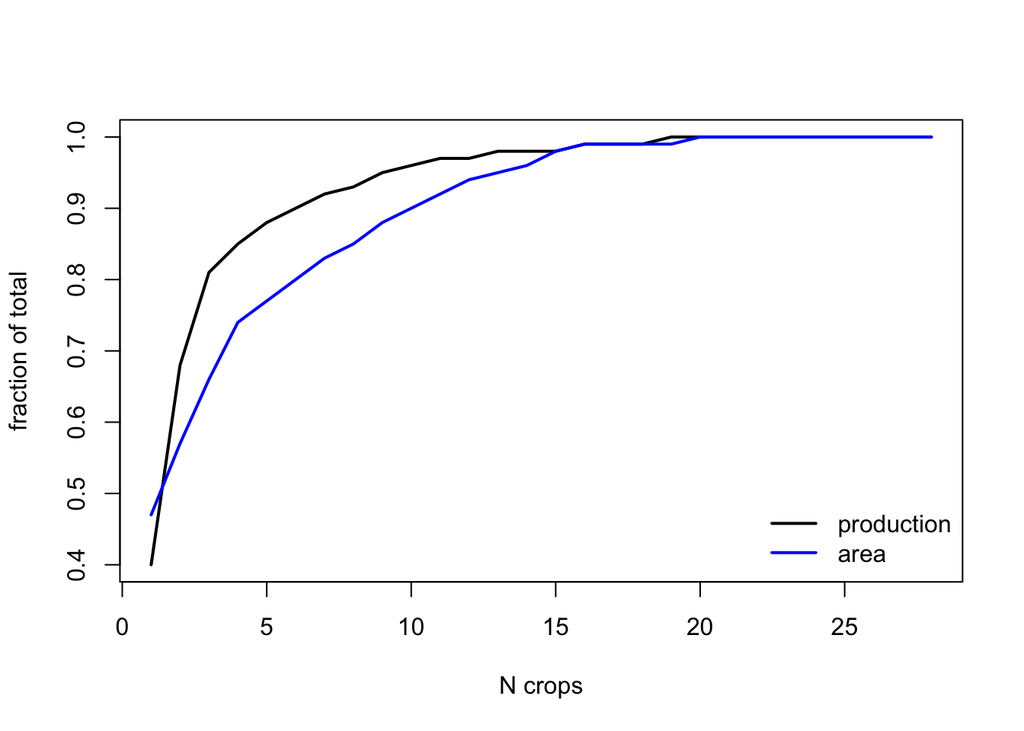

```r
options(stringsAsFactors = FALSE)
fao <- read.csv(full_path(p_dat, "zambia_crops_2008-2013.csv"))
# plot(fao[(fao$ElementName == "Area harvested") & (fao$ItemName == "Wheat"), "Value"])
crops <- unique(fao$ItemName)
type <- unique(fao$ElementName)[1:2]
crop_prod <- do.call(rbind, lapply(crops, function(x) {
 v <- sapply(type, function(y) mean(fao[(fao$ItemName == x) & (fao$ElementName == y), "Value"], na.rm = TRUE))
 cbind.data.frame("crop" = x, t(v))
}))
crop_prod <- crop_prod[grep("Total|Primary|Equivalent|Eqv", crop_prod$crop, invert = TRUE), ]
crop_prod <- crop_prod[!is.na(rowSums(crop_prod[, 2:3])), ]
names(crop_prod)[2] <- "area"
crop_prod$crop[grep("sugar", crop_prod$crop, ignore.case = TRUE)] <- "sugarcane"
crop_prod <- crop_prod[order(crop_prod$Production, decreasing = TRUE), ]
crop_prod$prod_prop <- round(crop_prod$Production / sum(crop_prod$Production), 2)
crop_prod$area_prop <- round(crop_prod$area / sum(crop_prod$area), 2)
crop_prod$prod_csum <- cumsum(crop_prod$Production)
crop_prod$prod_fcum <- round(crop_prod$prod_csum / sum(crop_prod$Production), 2)
crop_prod <- crop_prod[order(crop_prod$area, decreasing = TRUE), ]
crop_prod$area_csum <- round(cumsum(crop_prod$area))
crop_prod$area_fcum <- round(crop_prod$area_csum / sum(crop_prod$area), 2)
crop_prod$sel <- ifelse((crop_prod$area_fcum < 0.9) | (crop_prod$prod_fcum < 0.9), 1, 0)

plot(sort(crop_prod$prod_fcum), type = "l", ylab = "fraction of total", lwd = 2, xlab = "N crops")
lines(sort(crop_prod$area_fcum), col = "blue", lwd = 2)
legend("bottomright", legend = c("production", "area"), lwd = 2, lty = 1, col = c("black", "blue"), bty = "n")
```

```r
sel_crops <- sapply(strsplit(crop_prod$crop[crop_prod$sel == 1], ","), function(x) x[1])  # get crop names
sel_crops <- tolower(gsub(" |Seed|seed|nuts|potatoes|beans|s$", "", sel_crops))
sel_crops
```

```
##  [1] "maize"     "cassava"   "ground"    "cotton"    "soy"
##  [6] "tobacco"   "pulse"     "sweet"     "sunflower" "vegetable"
## [11] "sugarcane" "wheat"
```

2. Find which of these selected crops have Monfreda data available, and load them. Also load the same datasets from Licker et al (2010) for climate potential yields. Area and actual yields are from Monfreda et al (2008), downloaded [here](http://www.geog.mcgill.ca/landuse/pub/Data/175crops2000/NetCDF/). Crop these down to just Africa.

```r
yld_dir <- "~/eMaphepha_ami/Past_postdoc/Data/Crops/YieldGap/"
flder <- "area-yield"
ydat_nms <- dir(full_path(yld_dir, flder), pattern = "5")
yldnms <- sapply(sel_crops, function(x) ydat_nms[grep(tolower(x), ydat_nms)])
yldnms <- yldnms[which(sapply(yldnms, function(x) length(x)) == 1)]  # remove missing ones
```

```r
cropylds <- stack(lapply(yldnms, function(x) raster(full_path(yld_dir, full_path(flder, x)), level = 2)))
extent(cropylds)@xmin <- -180
extent(cropylds)@xmax <- 180
cropareas <- stack(lapply(yldnms, function(x) raster(full_path(yld_dir, full_path(flder, x)), level = 1)))
extent(cropareas)@xmin <- -180
extent(cropareas)@xmax <- 180

flder <- "potential"
ydat_nms <- dir(full_path(yld_dir, flder), pattern = "90")
yldnms <- sapply(sel_crops, function(x) ydat_nms[grep(tolower(x), ydat_nms)])
yldnms <- yldnms[which(sapply(yldnms, function(x) length(x)) == 1)]  # remove missing ones
potylds <- stack(lapply(yldnms, function(x) raster(full_path(yld_dir, full_path(flder, x)))))
extent(potylds)@xmin <- -180
extent(potylds)@xmax <- 180

# Crop them down to Africa
cropylds_af <- crop(cropylds, afgcs, filename = "external/ext_data/cropylds_af.tif")
names(cropylds_af) <- names(yldnms)
cropareas_af <- crop(cropareas, afgcs, filename = "external/ext_data/cropareas_af.tif")
names(cropareas_af) <- names(yldnms)
crop(potylds, afgcs, filename = "external/ext_data/potylds_af.tif")
potylds_af <- brick("external/ext_data/potylds_af.tif")
names(potylds_af) <- names(yldnms)
save(yldnms, file = "data/cropnames.rda")  # save the currently used crop names in data folder

# And project to Albers for larger area work
projectRaster(from = cropylds_af, to = afr10, progress = "text",
              filename = "external/ext_data/cropylds-af-p.tif")
projectRaster(from = cropareas_af, to = afr10, progress = "text",
              filename = "external/ext_data/cropareas-af-p.tif")
projectRaster(from = potylds_af, to = afr10, progress = "text",
              filename = "external/ext_data/potylds-af-p.tif")
cropylds_af_p <- brick("external/ext_data/cropylds-af-p.tif")
cropsareas_af_p <- brick("external/ext_data/cropareas-af-p.tif")
potylds_af_p <- brick("external/ext_data/potylds-af-p.tif")
```

3. Set up some masks of current cropland/non-cropland and urban areas

```r
afgcsr <- rasterize(afgcs, potylds_af[[1]])
# Cropland
cropland_dir <- "~/eMaphepha_ami/RSGIS/Base_data/Agriculture"
cropland <- raster(full_path(cropland_dir, "africa.cropland.tif"))
cropland <- crop(cropland, afgcsr)
cropland <- resample(cropland, afgcsr)
nocropland <- afgcsr - cropland

# Urban areas
urb_dir <- "~/eMaphepha_ami/RSGIS/Base_data/Africa/af_grumpv1_urextent_ascii_30/"
urb <- raster(full_path(urb_dir, "afurextents.asc"))
urb10 <- aggregate(urb, fact = 10)
urb10 <- resample(urb10, cropland, method = "ngb")
urb10 <- crop(urb10, cropland)

# Make a mask for farming out of the urban extent layer
nofarm <- (urb10 == 2) * 2
nofarm[nofarm == 2] <- 0
nofarm[nofarm == 0] <- 1
unfarmed <- nocropland * nofarm  # Mask applied to non farm fractions
unfarmed[unfarmed < 0] <- 1
projectRaster(unfarmed, to = afr10, filename = "external/ext_data/africa-unfarmed.tif", overwrite = TRUE)
unfarmed <- raster("external/ext_data/africa-unfarmed.tif")
```

And use that to figure out total current and potential production at 10 km resolution

```r
# Current production, confined to actual croplands
curprod <- sapply(1:nlayers(cropsareas_af_p), function(x) {
  r <- cropsareas_af_p[[x]]
  r[r < 0] <- 0
  rha <-  r * afha
  prod <- rha * cropylds_af_p[[x]]
  prod
})
brick(stack(curprod), filename = "external/ext_data/current-production.tif")
curprod <- brick("external/ext_data/current-production.tif")

unfarmed_ha <-  unfarmed * afha
potprod <- sapply(1:nlayers(potylds_af_p), function(x) {
  prod <- unfarmed_ha * potylds_af_p[[x]]
})
brick(stack(potprod), filename = "external/ext_data/potential-production.tif")
potprod <- brick("external/ext_data/potential-production.tif")
```

4. Carbon datasets. I am reusing most of the carbon data used in the Searchinger et al, (in revision) analysis to get an Africa wide dataset that I can downsample. I adapted some codde from `wet.savannas_Carbon.R`, but could not use the full approach that augments IGBP soil C with HWSD soils to account for wetlands and histosols.

```r
lpj_dir <- "~/eMaphepha_ami/Post_doc/Pubs+presentations/Wet_savannas/Wet_savannas_analysis/Beringer_04102012/"
wsdat_dir <-"~/eMaphepha_ami/RSGIS/Post_doc_data/Wet_savannas_spatial/"

vegc <- raster(full_path(wsdat_dir, "C_datasets/c_5m/vc.af.grd"))  # verified same as Tim's
soilc <- raster(full_path(lpj_dir, "lpj/ref_carbon_data/soilc.res.grd"))

# disaggregate and reproject to Albers 10 km
cpool <- lapply(list(vegc, soilc), function(x) {
 r <- disaggregate(x, fact = 3)
 ra <- projectRaster(r, afr10, progress = "text")
})
names(cpool) <- c("veg", "soil")

# convert to total carbon in pixel, and create total carbon layer
carbon <- lapply(cpool, function(x) (x * afha) / 1000)
carbon$tot <- calc(stack(carbon), sum)
brick(stack(carbon), filename = "external/ext_data/carbon.tif", overwrite = TRUE)
carbon <- brick("external/ext_data/carbon.tif")
```

5. Protected area and biodiversity data
- First is the older approach, where PAs and mammal diversity data are brought in and processed.

```r
bdiv_dir <- "~/eMaphepha_ami/RSGIS/Base_data/Protected_areas/All_Africa_PAs/"
setwd(bdiv_dir)
af_pas <- readOGR(dsn = "All_Africa_PAs.shp", layer = "All_Africa_PAs")
setwd(p_proj)

af_pas_r <- af_pas[af_pas@data$is_point == 0, ]  # Keeping in marine because some coastal parks are "marine"
af_pas_r@data <- af_pas_r@data[, c(1:2, 9:11, 15)]  # Reduce size of data table
length(af_pas_r)  # 5209
ramsar <- unique(af_pas_r@data$desig_eng[grep("Wetlands", af_pas_r@data$desig_eng)])  # Remove Ramsar sites
af_pas_r2 <- af_pas_r[!af_pas_r@data$desig_eng %in% ramsar, ]  # Remove RAMSAR
length(af_pas_r2)  # 5139

# Assign conversion probabilities
af_pas_r2@data$ConvProb <- rep(0, nrow(af_pas_r2))
af_pas_r2@data$ConvProb[af_pas_r2@data$desig_eng == "National Park"]  <- 1
af_pas_r2@data$ConvProb[grep("National Park", af_pas_r2@data$desig_eng)] <- 1
af_pas_r2@data$ConvProb[grep("Strict", af_pas_r2@data$desig_eng)] <- 1
af_pas_r2@data$ConvProb[grep("Scientific", af_pas_r2@data$desig_eng)] <- 1
af_pas_r2@data$ConvProb[grep("World Heritage", af_pas_r2@data$desig_eng)] <- 1
af_pas_r2@data$ConvProb[af_pas_r2@data$iucncat == "Ib"]  <- 1
af_pas_r2@data$ConvProb[af_pas_r2@data$iucncat == "II"] <- 1
af_pas_r2@data$ConvProb[af_pas_r2@data$iucncat == "III"] <- 1
af_pas_r2@data$ConvProb[af_pas_r2@data$iucncat == "Ib"] <- 2
af_pas_r2@data$ConvProb[grep("Botanical|Monument", af_pas_r2@data$desig_eng)] <- 2
af_pas_r2@data$ConvProb[grep("Provincial", af_pas_r2@data$desig_eng)] <- 2
af_pas_r2@data$ConvProb[grep("National Heritage", af_pas_r2@data$desig_eng)] <- 2
af_pas_r2@data$ConvProb[af_pas_r2@data$iucncat == "IV"] <- 3
af_pas_r2@data$ConvProb[af_pas_r2@data$iucncat == "V"] <- 3
af_pas_r2@data$ConvProb[grep("Voluntary|Private|Voluntary", af_pas_r2@data$desig_eng)] <- 3
af_pas_r2@data$ConvProb[grep("Forest", af_pas_r2@data$desig_eng)] <- 3
af_pas_r2@data$ConvProb[grep("Wildlife", af_pas_r2@data$desig_eng)] <- 3
af_pas_r2@data$ConvProb[grep("Catchment", af_pas_r2@data$desig_eng)] <- 3
af_pas_r2@data$ConvProb[grep("Game Farm", af_pas_r2@data$desig_eng)] <- 3
af_pas_r2@data$ConvProb[grep("Game Reserve", af_pas_r2@data$desig_eng)] <- 3
af_pas_r2@data$ConvProb[grep("Biosphere", af_pas_r2@data$desig_eng)] <- 4
af_pas_r2@data$ConvProb[af_pas_r2@data$iucncat == "VI"] <- 4
af_pas_r2@data$ConvProb[grep("ommunity|illage", af_pas_r2@data$desig_eng)] <- 4
af_pas_r2@data$ConvProb[grep("Hunting|hunting", af_pas_r2@data$desig_eng)] <- 4
af_pas_r2@data$ConvProb[grep("Forest", af_pas_r2@data$desig_eng)] <- 4
af_pas_r2@data$ConvProb[af_pas_r2@data$status %in% c("Proposed", "Recommended")] <- 5

# And the set the 300 odd remaining to class 3
rem <- unique(af_pas_r2@data$desig_eng[af_pas_r2@data$ConvProb == 0])
for(i in 1:length(rem)) {
  af_pas_r2@data$ConvProb[which(af_pas_r2@data$ConvProb == 0 & grep(rem[i], af_pas_r2@data$desig_eng))] <- 3
}

# Rasterize Africa and GS country level PAs
af_pas_r3 <- af_pas_r2
af_pas_r3@data <- af_pas_r3@data[, -c(2:6)]
Pls <- slot(af_pas_r3, "polygons")  # Fix orphaned polygn hole first
Pls1 <- lapply(Pls, checkPolygonsHoles)
slot(af_pas_r3, "polygons") <- Pls1
af_pas_alb <- spTransform(af_pas_r3, CRSobj = gspoly@proj4string)
over_gs <- over(af_pas_alb, gBuffer(gscnt, width = 0))
gs_pas <- af_pas_r3[which(over_gs == 1), ]
rasterize(af_pas_alb, afr10, field = "ConvProb", progress = "text",
          filename = "external/ext_data/af-pas-10km.tif")
af_pas_r <- raster("external/ext_data/af-pas-10km.tif")
#plot(pas.r, col = bpy.colors(5))

# Mammal diversity
load("external/ext_data/mamdiv.rda")
mamdiv <- disaggregate(m.r, fact = 3)
af_mamdiv <- projectRaster(mamdiv, afr10, progress = "text")  # 10 km mammal diversity for Africa
gs_mamdiv <- af_mamdiv * !is.na(gs_cnt_r)  # GS range country mammal diversity, 10 km
writeRaster(af_mamdiv, filename = "external/ext_data/af_mammal_div.tif")
af_mamdiv <- raster("external/ext_data/af_mammal_div.tif")
writeRaster(gs_mamdiv, filename = "external/ext_data/gs_mammal_div.tif")
gs_mamdiv <- raster("external/ext_data/gs_mammal_div.tif")
```

- Second, I am adding a new approach, which is to use the [GLC-Share](http://www.glcn.org/databases/lc_glcshare_en.jsp) landcover dataset to define natural vegetation cover, and then pass a moving window over that to calculate how natural the vegetation is in each neighborhood–this will allow areas that are fairly undisturbed to be favored.

```r
glc_dir <- "~/eMaphepha_ami/RSGIS/Base_data/Globe/Landcover/"

# Down the dominant landcover class layer
url <- "http://www.fao.org/geonetwork/srv/en/resources.get?id=47948&fname=GlcShare_v10_Dominant.zip&access=private"
download.file(url, method = "auto", destfile = full_path(glc_dir, "glc_share.zip"))
unzip(full_path(glc_dir, "glc_share.zip"), exdir = full_path(glc_dir, "glc_share"))
glc <- raster(full_path(glc_dir, "glc_share/glc_shv10_DOM.Tif"))
projection(glc) <- projection(afgcsr)
af_glc <- crop(glc, y = afgcs, file = full_path(glc_dir, "glc-africa.tif"), overwrite = TRUE)  # crop to Af
gdalwarp(srcfile = af_glc@file@name, dstfile = "external/ext_data/glc-africa-alb.tif",
         t_srs = af@proj4string@projargs, te = bbox(afr)[1:4], tr = c(1000, 1000), r = "near")
af_lc <- raster("external/ext_data/glc-africa-alb.tif")
af_nat_cov <- af_lc %in% c(3:11)  # include all classes but artificial and cropland
af_nat_cov <- mask(af_nat_cov, mask = afr)
w <- matrix(1, nrow = 21, ncol = 21)
af_nat_areas <- focal(af_nat_cov, w = w, fun = mean, na.rm = TRUE,
                      filename = "external/ext_data/af-natural-cover.gri", progress = "text")
writeRaster(af_nat_areas, filename = "external/ext_data/af-natural-cover.tif")
#file.remove(dir("external/ext_data/", pattern = "af-natural-cover.gr"))
af_nat_areas <- raster("external/ext_data/af-natural-cover.tif")  # 1 km version
af_nat_areas10 <- aggregate(af_nat_areas, fact = 9)
resample(af_nat_areas10, y = afr10, filename = "external/ext_data/af-natural-cover-10km.tif")
af_nat_areas10 <- raster("external/ext_data/af-natural-cover-10km.tif")
```

- Third, merge the biodiversity data into a biodiversity value grid

```r
a <- c(0.2, 0.01)   # Here is where weights applied to PAs can be changed
b <- cellStats(af_pas_r, range)
pawts <- coef(lm(a ~ b))
pas_p <- pawts[1] + af_pas_r * pawts[2]  # Reweight grid
bdmask <- is.na(pas_p)  # Make a mask of PAs for the BD layer
bd_p <- 1 - (af_mamdiv - cellStats(af_mamdiv, min)) / diff(cellStats(af_mamdiv, range))  # inverse BD prob
af_nat_p <- 1 - (af_nat_areas10 - cellStats(af_nat_areas10, min)) / diff(cellStats(af_nat_areas10, range))
pas_p[is.na(pas_p)] <- 0  # NAs to 0
writeRaster(af_nat_p * bd_p * bdmask + pas_p, filename = "external/ext_data/af-cons-priorities-10km.tif")
cons_p <- raster("external/ext_data/af-cons-priorities-10km.tif")

# Do this for GS region as well
```

6. Africa elevation data. I started by downloading the global grid from the WorldGrids website, which I would have accessed through R if the GSIF package was not somehow broken. So I manually downloaded to my directory from [here](http://worldgrids.org/doku.php?id=wiki:demsre3). I could have also downloaded using the getData() function from the raster package, but that’s tedious since I have to figure out the coordinates or download country by country. This will be used to create a cost distance surface, and maybe a ruggedness map to screen out certain areas from being potential farmland.

```r
dem <- raster("~/eMaphepha_ami/RSGIS/Base_data/elevation/demsre2a.tif")

#### DEM of Zambia (convert to topographic roughness
```

7. Downscale to country level. Notes:
- For the first round of doing this to redevelop tradeoff model, I am going to start with the 10 km resolution for faster development.
- The code below can be modified so that inputs at any scale can be created. E.g. for whole Africa inputs, or all GS, then a code can be specified to select the data for a specific region, such as Guinea savanna range countries, or a specific country.

```r
# This will be done in lapply if more than one country is being assessed
cnames <- "ZA"  # "GSR" could be added to specify data for all range states
```

```r
# Crops
# current
lapply(cnames, function(x) {
 fname <- full_path("external/ext_data/", paste(x, "-current-production.tif", sep = ""))
 b <- mask(crop(brick("external/ext_data/current-production.tif"), cntr_l[[x]]), af[af$fips_cntry == x,  ])
 writeRaster(b, filename = fname)
})

# potential
lapply(cnames, function(x) {
 fname <- full_path("external/ext_data/", paste(x, "-potential-production.tif", sep = ""))
 b <- mask(crop(brick("external/ext_data/potential-production.tif"), cntr_l[[x]]), af[af$fips_cntry == x,  ])
 writeRaster(b, filename = fname)
})
potprod_cnt <- lapply(cnames, function(x) {
 fname <- full_path("external/ext_data/", paste(x, "-potential-production.tif", sep = ""))
 brick(fname)
})

# Carbon
lapply(cnames, function(x) {
 fname <- full_path("external/ext_data/", paste(x, "-carbon.tif", sep = ""))
 b <- mask(crop(brick("external/ext_data/carbon.tif"), cntr_l[[x]]), af[af$fips_cntry == x,  ])
 writeRaster(b, filename = fname)
})
carbon_cnt <- lapply(cnames, function(x) {
 fname <- full_path("external/ext_data/", paste(x, "-carbon.tif", sep = ""))
 brick(fname)
})

# Biodiversity
lapply(cnames, function(x) {
  pas <- mask(crop(af_pas_r, cntr_l[[x]]), af[af$fips_cntry == x,  ])
  mam <- mask(crop(af_mamdiv, cntr_l[[x]]), af[af$fips_cntry == x,  ])
  nat <- mask(crop(af_nat_areas10, cntr_l[[x]]), af[af$fips_cntry == x,  ])  # just doing 10 km for now
  a <- c(0.2, 0.01)   # Here is where weights applied to PAs can be changed
  b <- cellStats(pas, range)
  pawts <- coef(lm(a ~ b))
  pas_p <- pawts[1] + pas * pawts[2]  # Reweight grid
  bdmask <- is.na(pas_p)  # Make a mask of PAs for the BD layer
  bd_p <- 1 - (mam - cellStats(mam, min)) / diff(cellStats(mam, range))  # inverse BD prob
  nat_p <- 1 - (nat - cellStats(nat, min)) / diff(cellStats(nat, range))
  bd_inpas <- bd_p * pas_p / pas_p  # BD in PAs
  pas_p[is.na(pas_p)] <- 0  # NAs to 0
  fname <- full_path("external/ext_data/", paste(x, "-cons-priorities.tif", sep = ""))
  writeRaster(nat_p * bd_p * bdmask + pas_p, filename = fname)
})
```

Here’s a plot of the biodiversity data. Might need to redo to check that low priority patch in the western end.

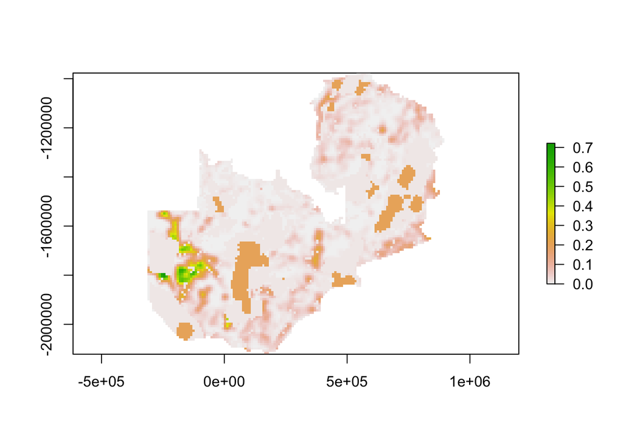

```r
cnt_cons_p <- lapply(cnames, function(x) {
  raster(full_path(p_dat, paste(x, "-cons-priorities.tif", sep = "")))
})
plot(cnt_cons_p[[1]])
```

8. Now that we have those datasets, let’s figure out how to do the cropland share. First create some necessary inputs regarding cropland area, standardized potential yields and cropland area for the country in question

```r
# Production areas
lapply(cnames, function(x) {
 fname <- full_path("external/ext_data/", paste(x, "-crop-areas.tif", sep = ""))
 b <- mask(crop(brick("external/ext_data/cropareas-af-p.tif"), cntr_l[[x]]), af[af$fips_cntry == x,  ])
 writeRaster(b, filename = fname)
})

# Potential yields
lapply(cnames, function(x) {
 fname <- full_path("external/ext_data/", paste(x, "-potential-yields.tif", sep = ""))
 b <- mask(crop(brick("external/ext_data/potylds-af-p.tif"), cntr_l[[x]]), af[af$fips_cntry == x,  ])
 writeRaster(b, filename = fname, overwrite = TRUE)
})

# Standardized potential yields are also the probability of conversion
lapply(1:length(cnames), function(x) {
 nm <- cnames[x]
 r <- potylds_cnt[[x]]
 l <- lapply(1:nlayers(r), function(y) (r[[y]] - cellStats(r[[y]], min)) / diff(cellStats(r[[y]], range)))
 brick(stack(l), filename = full_path("external/ext_data/", paste(nm, "-potential-yields-std.tif", sep = "")))
})
```

Make a few plots of these

```r
# First read in relevant grids
currprod_cnt <- lapply("ZA", function(x) {
 fname <- full_path(p_dat, paste(x, "-current-production.tif", sep = ""))
 b <- brick(fname)
 names(b) <- names(yldnms)
 b
})
cropareas_cnt <- lapply(cnames, function(x) {
 fname <- full_path(p_dat, paste(x, "-crop-areas.tif", sep = ""))
 b <- brick(fname)
 names(b) <- names(yldnms)
 b
})
names(cropareas_cnt[[1]]) <- names(yldnms)
potylds_cnt <- lapply(cnames, function(x) {
 fname <- full_path(p_dat, paste(x, "-potential-yields.tif", sep = ""))
 b <- brick(fname)
 names(b) <- names(yldnms)
 b
})
potylds_cnt_std <- lapply(cnames, function(x) {
 fname <- full_path(p_dat, paste(x, "-potential-yields-std.tif", sep = ""))
 b <- brick(fname)
 names(b) <- names(yldnms)
 b
})

par(mfrow = c(2, 2), height = 700, width = 700, mar = c(1, 2, 1, 3), oma = c(0, 0, 0, 1))
```

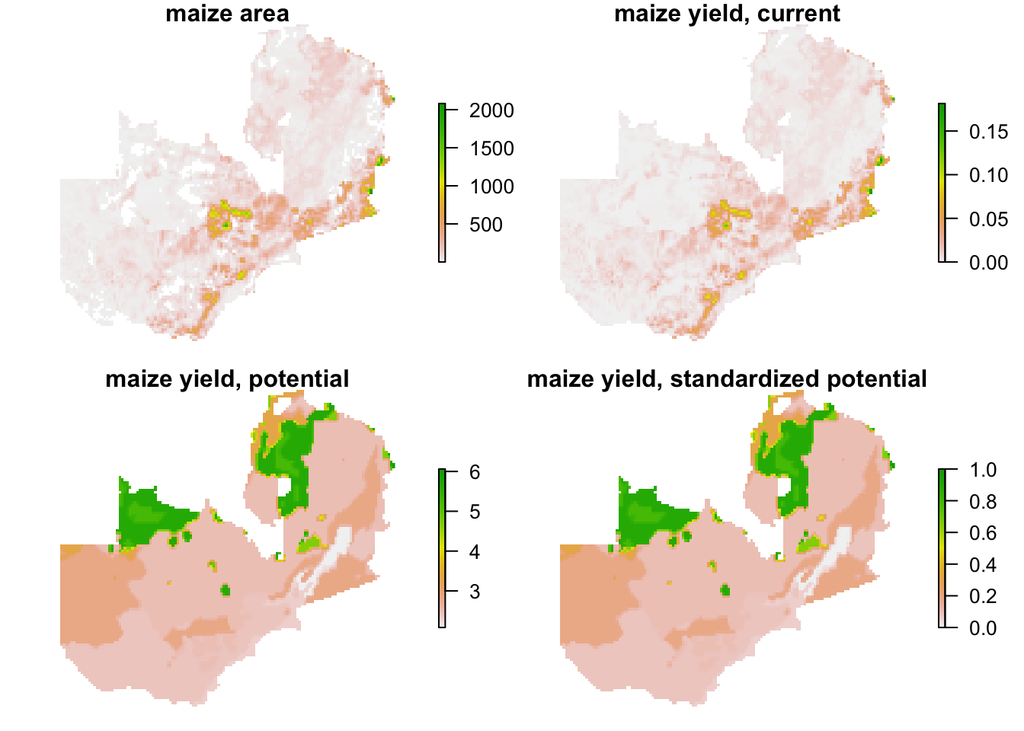

```r
plot(currprod_cnt[[1]][[1]], main = "maize area", axes = FALSE, box = FALSE)
plot(cropareas_cnt[[1]][[1]], main = "maize yield, current", axes = FALSE, box = FALSE)
plot(potylds_cnt[[1]][[1]], main = "maize yield, potential", axes = FALSE, box = FALSE)
plot(potylds_cnt_std[[1]][[1]], main = "maize yield, standardized potential", axes = FALSE, box = FALSE)
```

Figure out some values based on country-level statistics also: each crop’s proportion of total planted area and total production in the country. That is an entryway to figuring out some sort of share based on suitability.

```r
# Select data from production table
crop_prod_sel <- crop_prod[sapply(names(yldnms), function(x) grep(x, crop_prod$crop, ignore.case = TRUE)), ]
crop_prod_sel$seas <- ifelse(crop_prod_sel$crop == "Wheat", 2, 1)  # 1 for summer crops, 2 for winter
crop_sel_tab <- crop_prod_sel[, c(1, 4:5, 11)]
crop_sel_tab$crop <- names(yldnms)
crop_sel_tab
```

```
##         crop prod_prop area_prop seas
## 4      maize      0.28      0.47    1
## 9    cassava      0.13      0.10    1
## 13    ground      0.02      0.10    1
## 15    cotton      0.02      0.07    1
## 12       soy      0.02      0.03    1
## 11     pulse      0.00      0.03    1
## 14 sunflower      0.00      0.02    1
## 10 sugarcane      0.40      0.02    1
## 1      wheat      0.02      0.02    2
```

2. Sharing pixels between crops on the same calendar.
- Share of crop in pixel should be determined by its potential productivity, and its planted area, given the following rules:
  - For any pixel, the crop having the highest potential (standardized) productivity will be given the maximum share of cropland.
  - The remaining crops will be allocated the remaining area in proportion to how much area they should normally occupy in that area.
  - The area each crop normally occupies is determined as the maximum of these two values:
    1. The share of total area each has historically occupied in the country
    2. Each crop’s share of currently occupied cropland
  - This allows for some spatial correlation to be factored into cropland expansion (provided it is kriged a bit), in that areas near areas that have historically been farmed for that crop are more likely to be farmed for that crop in the future given the infrastructure and/or other socio-economic factors that lead a particular crop to be planted in a particular area.
- Allocations can be altered as a function of demand growth. E.g. if the growth in demand for soybean is higher than the growth in demand for maize, then the area allocated to maize can be reduced by some proportion.
3. Ultimately, an optimization function should be used to minimize the total area planted across all crops while hitting their necessary targets, after other land-use constraints are applied (e.g. carbon minimization).
4. A scaling function will also be needed, such that as the resolution of analysis increases, the share of a crop in any given pixel should expand such that a pixel may be dominated by the few most dominant crops.

First step in this. Create a brick that has the starting cropland shares across all crops.

```r
# Start with a few small helper functions
which_max_fun <- function(x, na.rm = na.rm) {
  if(any(!is.na(x))) {
    o <- which(x == max(x, na.rm = na.rm))[1]
  } else {
    o <- NA
  }
  as.integer(o)
}
max_fun <- function(x, na.rm = na.rm) {
  if(all(is.na(x))) {
    o <- NA
  } else {
    o <- max(x, na.rm = na.rm)
  }
  o
}

seas_max <- 0.5  # sets up the maximum share of cropland that any crop can have in a given pixel
lapply(1:length(cnames), function(x) {
  nm <- cnames[x]
  area_props <- ifelse(crop_prod_sel$seas == 1, crop_prod_sel$area_prop * 1.2, seas_max)
  area_props_sameseas <- area_props[crop_prod_sel$seas == 1]
  ta <- calc(cropareas_cnt[[x]], sum)
  prop <- cropareas_cnt[[x]] / ta  # convert planted areas to local proportion of total crop area
  prop <- stack(sapply(1:nlayers(prop), function(x) {
   r <- prop[[x]]
   r[(r > seas_max)] <- seas_max
   r
  }))  # st max in any area to seas_max, to prevent
  names(prop) <- crop_sel_tab$crop
  #plot(prop[[2]] > seas_max)
  #plot(prop)
  potyld_sameseas <- potylds_cnt_std[[x]]  # potential yields for crops growing in the same season
  #potyld_sameseas <- potyld_sameseas[[crop_sel_tab$crop[(which(crop_sel_tab$seas == 1))]]]
  potmax <- calc(potyld_sameseas, fun = which_max_fun, na.rm = TRUE)  # which crop highest yield pot
  potmax_bin <- stack(sapply(1:nlayers(potyld_sameseas), function(x) potmax == x))  # as binary stack
  #plot(potmax_bin)
  areas <- stack(sapply(1:nlayers(prop), function(y) {
     r <- prop[[y]]
     r[!is.na(r)] <- crop_sel_tab$area_prop[y]
     s <- stack(r, prop[[y]])
     o <- calc(s, fun = max_fun, na.rm = TRUE)
  }))  # calculate maximum area for each crop, as function of
  names(areas) <- crop_sel_tab$crop
  #areas <- areas[[crop_sel_tab$crop[(which(crop_sel_tab$seas == 1))]]]
  areamax <- calc(areas, fun = which_max_fun, na.rm = TRUE)  # which crop highest yield pot
  areamax_bin <- stack(sapply(1:nlayers(areas), function(x) areamax == x))

  # Assign area share
  out_areas <- stack(sapply(1:nlayers(areas), function(x) {
    both  <- ((potmax_bin[[x]] == 1) & (areamax_bin[[x]] == 1)) * seas_max  # max yield & area = seas_max
    amax <- ((potmax_bin[[x]] == 0) & (areamax_bin[[x]] == 1)) * areas[[x]]  # max area = areas
    ymax <- ((potmax_bin[[x]] == 1) & (areamax_bin[[x]] == 0)) * areas[[x]]  # max yield only = areas
    none <- ((potmax_bin[[x]] == 0) & (areamax_bin[[x]] == 0)) * area_props[x]  # max area = areas
    out <- both + amax + ymax + none
  }))
  #plot(calc(out_areas[[1:8]], sum))
  names(out_areas) <- names(areas)
  # Segregate out same season crops from off-season crops
  sameseas <- which(crop_prod_sel$seas == 1)  # indices
  offseas <- which(crop_prod_sel$seas == 2)  # indices
  ta <- calc(out_areas[[sameseas]], sum) # total proportion of area under same season crops
  out_areas_r <- stack(sapply(sameseas, function(x) {
    r <- out_areas[[x]]
    ro <- (r / ta)
  }))
  out_stack <- stack(out_areas_r, out_areas[[offseas]])  # combine standardized same season with off-season
  names(out_stack) <- c(names(areas[[sameseas]]), names(areas[[offseas]]))
  fname <- full_path("external/ext_data/", paste(nm, "-crop-convert-fractions-base.tif", sep = ""))
  brick(out_stack, filename = fname, overwrite = TRUE)  # write out the base fractions
})
```

The next step will be to write a function that can alter the shares of cropland in proportion to demand, but I will first develop the basic model, absent the road cost distance function (11:50; 6/1/2015).